# 텍스트분석 뉴스레터: 2023년 5월

sung won kang

2023 5 25

- 한국환경연구원 텍스트 수집 도구는 2023년 5월 23일까지 네이버 기사 데이터와 환경부 문헌 데이터를 제공한다.아래 뉴스레터에서는 2023년 5월 23일을 기점으로 30일 이전까지 수집한 자료를 사용한다.

### A. Text 데이터

분석 대상 Text Data는 다음 두 종류의 문헌을 자료이다.

1. NAVER 환경 뉴스 : 2023년 4월 24일-2023년 5월 23일 NAVER 뉴스> ‘사회’ >‘환경’ 부문에 게시된 뉴스
2. 환경부 문건 : 2023년 4월 24일-2023년 5월 23일 환경부홈페이지에 게시된 환경부 보도자료 및 e-환경뉴스

’NAVER 환경 뉴스’는 환경정책의 수요자인 국민의 환경과 관련된 관심사를 전달하는 텍스트 자료이다. 그리고 ’환경부 문건’은 환경정책의 공급자인 환경부의 관심사를 전달하는 텍스트 자료이다. 이 두 자료의 키워드를 비교하여 환경정책 공급자의 관심사가 환경정책 수요자의 관심사에 조응하는지 여부를 점검한다.

### B. 키워드 빈도분석

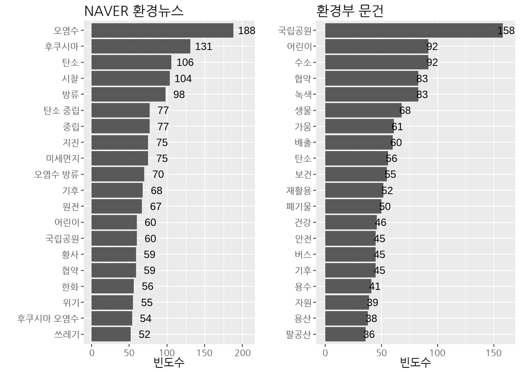

눈에 띄는 차이는 다음과 같이 정리할 수 있다.

- 첫째, 네이버 환경뉴스에는 빈도수가 높은 상위 20개 키워드 중 ‘후쿠시마’,‘오염수’,‘방류’,‘원전’ 등 일본 후쿠시마지역 원자력발전소 방류수 관련 키워드가 6개 발견되었지만 환경부 문건의 빈도수 상위 20개 키워드에는 이에 상응하는 키워드가 발견되지 않았다.
- 둘째, 네이버 환경뉴스에는 빈도수가 높은 상위 20개 키워드 중 ‘지진’,‘미세먼지’ 등 자연재해 혹은 대기오염 관련 키워드 2개가 발견되었지만 환경부 문건의 빈도수 상위 20개 키워드에는 이에 상응하는 키워드가 발견되지 않았다.
- 셋째, 환경부 문건의 빈도수 상위 20개 키워드 중에는 ‘가뭄’,‘용수’와 같이 봄 가뭄 대비 용수 공급과 관련된 키워드가 포함되지만 네이버 환경뉴스에서는 이에 상응하는 키워드가 발견되지 않았다. 단, ’기후’,‘위기’ 등 광범위한 기후변화와 관련된 키워드는 발견되었다.

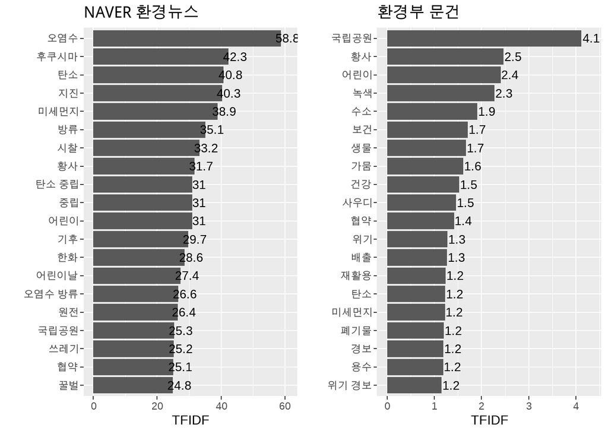

이와 같은 경향은 TF_IDF 값이 높은 20개의 키워드를 추출하여 비교하여도 확인된다. Figure 2는 TF_IDF를 기준으로 추출한 상위 20개 키워드의 TF_IDF 값을 보여준다. Figure 2에서도 확인할 수 있듯이

- “오염수”,” 후쿠시마”,“방류”,“원전”과 같은 키워드는 NAVER 뉴스에서만 찾아볼 수 있고
- “가뭄”,“용수”와 같은 키워드들은 환경부 문건에서만 찾아 볼 수 있다.

### C.키워드 관련 뉴스

네이버 환경뉴스 키워드와 환경부 문건 키워드간의 차이의 원인을 파악하기 위해서 두 문헌에서 단순빈도가 가장 높은 10개 키워드 중 서로 상이한 키워드가 포함된 문헌의 제목들을 비교하였다.

- 네이버 환경뉴스에서 단순빈도가 높은 10개 키워드 중 환경부 문건의 단순빈도가 높은 20개 키워드에 포함되지 않은 키워드는 [오염수, 후쿠시마, 시찰, 방류, 탄소 중립, 중립, 지진, 미세먼지, 오염수 방류]이다.
- 환경부 문헌에서 단순빈도가 높은 10개 키워드 중 네이버 환경뉴스에서 단순빈도가 높은 20개 키워드에 포함되지 않은 키워드는 [수소, 녹색, 생물, 가뭄, 배출, 보건]이다.

네이버 환경뉴스에서만 파악된 키워드 중 ‘탄소 중립’,‘중립’은 환경부 문헌 키워드 중 탄소중립과 관련된 키워드인 ’녹색’,‘탄소’,’기후’등과 관련이 있다.

1. ‘후쿠시마’,‘오염수’, ‘방류’,‘원전’,’시찰’을 제목에 포함하는 기사들은 후쿠시마 원전 오염수 방류와 관련된 기사들이 주종을 이룬다. 같은 기간 환경부 문헌 중 ’방류’를 포함한 문건이 1건 있었는데 “멸종위기 1급 어류 좀수수치, 전남 고흥 고읍천에 방류’라는 제목의 문건이어서 후쿠시마 원전 방류수와는 관계가 없었다.

| Title |
| --- |
| 한일 시민단체, 日경산성서 오염수 방류 반대 집회 |
| 日경산성, 韓시민단체 오염수 방류 항의서한 수령 거부 |
| ‘후쿠시마 오염수 방류 금지 및 수산물 수입 반대’…부안군의회, 건의안 |
| 탈핵운동가로 변신한 전 일본 원전 설계자의 ‘원전의 위험성’ 경고 |
| 제주도민 10명 중 9명 “日 원전 오염수 방류 영향 심각할 것” |
| “일본 원전 오염수 방류 안 돼”…부산시의회 결의문 채택 |
| 후쿠시마 방사성 오염수 해양투기 저지 선언 |
| “도심 하천에 맑은 물 콸콸”…수원시 ‘하수처리시설 방류수 재이용’ 추진 |
| 제주도민 10명 중 7명 “정부, 日 원전 오염수 방류 막아야” |
| 제주도민 70% “정부가 日 원전 오염수 방류 반대 표명해야” |

| Title |
| --- |
| 재활용 공정 현장 시찰하는 한화진 환경부 장관 |
| 환경단체, 후쿠시마 시찰단 합의에 “요식행위…방류 중단해야” |
| [속보] 정부, 후쿠시마 오염수 시찰단 23∼24일 파견 |
| 김동연 “’면죄부 시찰단’이 아니라 ’국민검증단’이 필요하다” |
| IAEA 검증과 별개로 후쿠시마 오염수 시찰…실효성은 얼마나 |
| 오염수 방류 밀어붙이는 일본…‘한국 시찰단’ 들러리 되나 |
| 일본이 찍은 날짜에 시찰? ‘오염수 방류 OK’ 국제기구 재탕 우려 |
| 환경단체, 후쿠시마 시찰단 합의에 “요식행위…독립검증 필요”(종합) |
| 오염수 방류 코앞에 두고 후쿠시마 파견…시찰단의 3가지 과제 |
| 후쿠시마 시찰단 23~24일 파견…일본과 규모·세부내용 조율 중 |

2. ’지진’을 제목에 포함하는 기사들은 4월 23일부터 4월 27일까지 강원 동북 해상에서 10여차례 발생한 지진과 관련된 기사들이었다. 같은 기간 환경부 문헌 중 ’지진’을 포함한 문건은 존재하지 않았다.

| Title |
| --- |
| 이틀새 강원 동해 북동쪽 바다서 13차례 소규모 지진 |
| [속보]지진 위기경보 ‘관심’ 단계 발령···강원도 해역서 지진 15차례 발생 |
| 강원 동해시 북동쪽 바다서 이틀째 15차례 지진… 위기경보 ‘관심’ 단계 발령 |
| 강원도 동해시 북동쪽 바다서 이틀간 13차례 지진 반복 |
| 강원 동해 앞바다서 규모 3.5 지진…오늘만 3.0 이상 두번째 |
| 동해 해역 규모 3.1 지진…사흘새 17회 흔들림 감지 |
| 강원 동해 앞바다 규모 3.1 지진…2.0 이상 지진만 6번째 |
| 강원 동해서 사흘간 지진 17회…행안부, 위기경보 ‘관심’ 발령 |
| 동해 해역 규모 3.5 지진…사흘새 17회 흔들려 |
| 사흘간 17차례… 강원 동해시 바다서 또 지진 |

3. ’미세먼지’을 제목에 포함하는 기사들은 겨울철 도로 청소를 통한 미세먼지 저감성과, 미세먼지 저감을 위한 기관 간 협력 등 미세먼지 저감 노력 및 성과에 관한 기사가 주종을 이루었다. 같은 기간 환경부 문헌 중 ’미세먼지’를 포함한 문건은 3건 존재하였는데 역시 미세먼지 저감성과 및 미세먼지 저감을 위한 노력과 관련이 있었다.
- ‘미세먼지’ 관련 naver 환경 기사

| Title |
| --- |
| 부산항만공사·환경공단, 부산항 도로 미세먼지 저감 협력 |
| 환경공단·항만공사, 부산항 일대 미세먼지 저감 ‘맞손’ |
| “첨단장비로 미세먼지 배출 단속”…환경과학원 성과 공유 |
| 겨울철 도로 청소하니…‘재비산’ 미세먼지 농도 43% 감소 |
| “미세먼지 계절관리제 기간 도로청소로 먼지 44% 줄여” |
| 환경부, 도로청소차량 운용 미세먼지 절반↓…평균 43.7% 감소 |
| 도로 물청소로 미세먼지 40% 넘게 줄었다 |
| 도로 청소했더니 다시 날리는 미세먼지 44% 줄었다 |
| 부산항만공사, 부산환경공단과 미세먼지 저감 위해 ‘맞손’ |
| 미세먼지 줄이는 ‘맑은학교 만들기’, 아이들 건강 지킴이 |

- ‘미세먼지’ 관련 환경부 문건

| Title |
| --- |
| 495개 집중관리도로 청소 전후 미세먼지 측정, 평균 43.7% 감소 |
| 한중, 황사·미세먼지 저감 협력 강화 |
| 제4차 미세먼지 계절관리제 시행 결과 공개 |

환경부 문헌에서 가장 빈도가 높은 10개 키워드 중 네이버 뉴스에서 가장 빈도가 높은 키워드 20개에 포함되지 않은 키워드는 “수소”,“녹색”,“생물”, “가뭄”,“배출”, “보건” 이다. 2023년 4월 24일부터 5월 23일까지 게시된 환경부 문헌 중 이들 키워드를 제목에 포함하는 환경부 문헌은 다음과 같다.

1. ‘수소’,‘녹색’을 제목에 포함하는 문헌은 온실가스 배출랑 저감 정책, ’배출’을 제목에 포함하는 문헌 대기오염물질 배출량 저감 정책과 관련이 있었다. ’수소’ 및 ‘녹색’을 포함하는 문헌은 네이버 환경기사 중 ’탄소 중립’ 혹은 ’중립’을 제목으로 하는 기사와 관심사가 유사하다. 그리고 ’배출’을 포함하는 문헌은 네이버 환경기사 중 ’미세먼지’를 포함하는 기사와 관심사가 유사하다.

| Title |
| --- |
| 첨단장비로 대기오염물질 불법배출 집중관리 |
| 환경기업의 의견에서 녹색산업의 길을 묻다 |
| 수소 생산하며 나온 이산화탄소, 깨끗한 물 만들 때 쓴다…온실가스 감축 |
| 기업 통근버스, 수소버스로 전환… 환경부·기업·지자체·운수사 업무협약 |
| 환경부, 중동에 녹색산업 수주지원단 파견 |
| 환경부, 세계 최대 액화수소 생산시설 구축 진행 상황 점검 |
| 사우디에서 녹색기술 교류의 장을 열다 |
| 한-사우디 정부, 녹색전환에 힘 합치다 |
| 한국형 녹색채권 3.9조원 발행, 재생에너지, 무공해 운송 수단 등에 투자 |

2. ‘생물’,’보건’을 제목에 포함하는 문헌들은 특정한 경향을 찾기 어려웠다.

| Title |
| --- |
| 섬지역 생물 샅샅이 살핀다…저탄소 조사선 섬누림호 취항 |
| 제101회 어린이날, 환경보건 체험 즐겨보세요 |
| 국립생물자원관, ‘생물 사랑 어린이 대축제’ 개최 |
| 국립생태원, 멸종위기생물 보호 등 다채로운 어린이날 행사 개최 |
| 제1회 국립공원 생물다양성 대탐사, 태안해안에서 개최 |
| 낙동강생물자원관, 미세조류 관리 종사자 대상으로 실습과정 교육 |
| 환경부, 지역 환경보건 정책 지원을 위한 지자체 간담회 개최 |
| 자외선에 내성 가진 미생물 발견…화장품 원료 활용 후속 연구 추진 |
| 생물다양성 보존 약속, 우리 모두 실천해요… 생물다양성의 날 기념식 개최 |
| 제3기 어린이용품 환경보건 시장감시단 발족 |

3. ‘가뭄’을 제목에 포함하는 문헌들은 금강권에서 발생한 가뭄 ’관심’ 및 ’주의’단계를 안내하는 문헌 및 1분기에 있었던 가뭄단계 해제 안내 문헌이 주종을 이루었다.

| Title |
| --- |
| 금강권역 대청댐, 가뭄 ‘관심’ 단계 진입 |
| 2기 국가물관리위원회 첫 회의개최, 영산강·섬진강유역 중장기 가뭄대책 등 심의·의결 |
| 금강권역 보령댐, 가뭄 ‘주의’ 단계 진입 |
| 가뭄단계 관리 11곳 댐 중에서 주암댐과 수어댐 가뭄단계 해제 |

### D. 정리

2023년 4월 24일-2023년 5월 23일 게시된 네이버 환경뉴스와 환경부 문헌을 비교한 결과를 요약하면 다음과 같다.

1. 네이버 기사로부터 당시 후쿠시마 원전 오염수 방류 및 4월 말에 발생한 강원 동해 일대 지진에 대한 관심이 컸음을 유추할 수 있다. 이에 조응하는 환경부 문헌은 찾아보기 어려웠는데, 이는 원전은 외교 및 에너지 관련 사안이고, 지진은 방재 관련 사안이어서 환경부 소관 업무와는 거리가 있기 때문에 나타나는 현상으로 보인다.
2. 환경부 문헌으로부터 이 시기 환경부는 수소차, 녹새기술 등을 통해서 온실가스 배출량을 감축하는 정책을 추진하고 있었음을 알 수 있다. 이는 당시 기후변화에 대한 국민의 관심에 조응하는 정책대응임을 알 수 있다.
3. 환경부 문헌으로부터 이 시기 환경부는 봄철 가뭄 관련 정보를 전달하는 문헌을 공표하였음을 알 수 있다. 반면 가뭄에 대한 이 시가 NAVER 뉴스의 관심은 이 시기에는 상대적으로 적었다.